# Data Preprocessing and Initial Analysis using Pandas

# Task 1

### Sept-19-2024

### In the dataset `breast_cancer_dataset.csv`:

### Each row is a sample and column is a feature (or label).

### Each sample has a patient ID (first column) and label (second column) with values "M" for malignant and "B" for benign.

#### 0. Load the dataset and print the top 5 rows.

```python
import pandas as pd
import numpy as np

df = pd.read_csv('data/breast_cancer_dataset.csv', header = None)

df.head()
```

|  | 0 | 1 | 2 | 3 | 4 | 5 | 6 | 7 | 8 | 9 | ... | 22 | 23 | 24 | 25 | 26 | 27 | 28 | 29 | 30 | 31 |
| --- | --- | --- | --- | --- | --- | --- | --- | --- | --- | --- | --- | --- | --- | --- | --- | --- | --- | --- | --- | --- | --- |
| 0 | 842302 | M | 17.99 | 10.38 | 122.80 | 1001.0 | 0.11840 | 0.27760 | NaN | 0.14710 | ... | 25.38 | 17.33 | 184.60 | 2019.0 | 0.1622 | 0.6656 | 0.7119 | 0.2654 | 0.4601 | 0.11890 |
| 1 | 842517 | M | 20.57 | 17.77 | 132.90 | 1326.0 | 0.08474 | 0.07864 | 0.0869 | 0.07017 | ... | 24.99 | 23.41 | 158.80 | 1956.0 | 0.1238 | 0.1866 | 0.2416 | 0.1860 | 0.2750 | 0.08902 |
| 2 | 84300903 | M | 19.69 | 21.25 | 130.00 | 1203.0 | 0.10960 | 0.15990 | 0.1974 | 0.12790 | ... | 23.57 | 25.53 | 152.50 | 1709.0 | 0.1444 | 0.4245 | 0.4504 | 0.2430 | 0.3613 | 0.08758 |
| 3 | 84348301 | M | 11.42 | 20.38 | 77.58 | 386.1 | 0.14250 | 0.28390 | 0.2414 | 0.10520 | ... | 14.91 | 26.50 | 98.87 | 567.7 | 0.2098 | 0.8663 | 0.6869 | NaN | 0.6638 | 0.17300 |
| 4 | 84358402 | M | 20.29 | NaN | 135.10 | 1297.0 | NaN | 0.13280 | 0.1980 | 0.10430 | ... | 22.54 | 16.67 | 152.20 | 1575.0 | 0.1374 | 0.2050 | 0.4000 | NaN | 0.2364 | 0.07678 |

5 rows × 32 columns

#### 1. Count and print the number of samples and features in the dataset.

```python
num_samples, num_columns = df.shape
num_features = num_columns
print(f"Number of samples: {num_samples}")
print(f"Number of features: {num_features-1}")
```

```
Number of samples: 569
Number of features: 31
```

#### 2. What are the means, standard deviations, minimum and maximum values of each of the features? Note, only print out these values, nothing else (i.e. do not print the 25%, 50%, 75% percentiles).

```python
filter_stats = df.describe().loc[['mean', 'std', 'min', 'max']]
print(filter_stats)
```

```
                0          2          3           4            5         6   \
mean  3.037183e+07  14.158262  19.283907   91.969033   654.889104  0.096565
std   1.250206e+08   3.607291   4.294333   24.298981   351.914129  0.014022
min   8.670000e+03   6.981000   9.710000   43.790000   143.500000  0.052630
max   9.113205e+08  28.110000  39.280000  188.500000  2501.000000  0.163400

            7         8         9         10  ...         22         23  \
mean  0.104341  0.088510  0.048919  0.181162  ...  16.187581  25.677223
std   0.052813  0.079294  0.038803  0.027414  ...   4.754326   6.146258
min   0.019380  0.000000  0.000000  0.106000  ...   7.930000  12.020000
max   0.345400  0.426800  0.201200  0.304000  ...  36.040000  49.540000

              24           25        26        27        28        29  \
mean  107.046844   880.583128  0.132369  0.253408  0.272188  0.114898
std    33.692024   569.356993  0.022832  0.156952  0.208624  0.065471
min    50.410000   185.200000  0.071170  0.027290  0.000000  0.000000
max   251.200000  4254.000000  0.222600  1.058000  1.252000  0.290300

            30        31
mean  0.290415  0.083946
std   0.062008  0.018061
min   0.156500  0.055040
max   0.663800  0.207500

[4 rows x 31 columns]
```

#### 3. Which features have missing values? For each feature, how are the missing values denoted (i.e., what are the values)?

```python
missing_values = df.isnull().sum()
features_with_missing = missing_values[missing_values > 0]
print("Features with missing values:")
print(features_with_missing)
```

```
Features with missing values:
2     95
3     98
6     61
8     77
12    29
13    53
14    76
16    12
19    45
20    23
22    27
24    62
27     7
29    68
30    20
dtype: int64
```

The missing values are denoted as **NaN**.

#### 4. Replace all missing values with the median value of each feature and print the top 10 rows of the dataframe before and after the replacement.

```python
print("Top 10 rows before replacement:")
print(df.head(10))

features = df.iloc[:, 2:]

medians = features.median()
features_filled = features.fillna(medians)

df.iloc[:, 2:] = features_filled

print("Top 10 rows after replacement:")
print(df.head(10))
```

```
Top 10 rows before replacement:
         0  1      2      3       4       5        6        7        8   \
0    842302  M  17.99  10.38  122.80  1001.0  0.11840  0.27760      NaN
1    842517  M  20.57  17.77  132.90  1326.0  0.08474  0.07864  0.08690
2  84300903  M  19.69  21.25  130.00  1203.0  0.10960  0.15990  0.19740
3  84348301  M  11.42  20.38   77.58   386.1  0.14250  0.28390  0.24140
4  84358402  M  20.29    NaN  135.10  1297.0      NaN  0.13280  0.19800
5    843786  M  12.45  15.70   82.57   477.1  0.12780  0.17000  0.15780
6    844359  M  18.25  19.98  119.60  1040.0  0.09463  0.10900  0.11270
7  84458202  M  13.71  20.83   90.20   577.9  0.11890  0.16450  0.09366
8    844981  M  13.00  21.82   87.50   519.8      NaN  0.19320      NaN
9  84501001  M  12.46  24.04   83.97   475.9  0.11860  0.23960      NaN

        9   ...     22     23      24      25      26      27      28      29  \
0  0.14710  ...  25.38  17.33  184.60  2019.0  0.1622  0.6656  0.7119  0.2654
```

[output cut: 61 more lines]

#### 5. Standardize all the features to have 0 mean and 1 standard deviation. Print out the top 10 rows of the dataframe before and after standardization. Remember, column 0 is the patient ID so do not standardize this but make sure it's not dropped. Plot a histogram of values after standardization for feature 10.

```
Top 10 rows before standardization:
         0  1      2      3       4       5         6        7        8   \
0    842302  M  17.99  10.38  122.80  1001.0  0.118400  0.27760  0.06168
1    842517  M  20.57  17.77  132.90  1326.0  0.084740  0.07864  0.08690
2  84300903  M  19.69  21.25  130.00  1203.0  0.109600  0.15990  0.19740
3  84348301  M  11.42  20.38   77.58   386.1  0.142500  0.28390  0.24140
4  84358402  M  20.29  18.75  135.10  1297.0  0.095955  0.13280  0.19800
5    843786  M  12.45  15.70   82.57   477.1  0.127800  0.17000  0.15780
6    844359  M  18.25  19.98  119.60  1040.0  0.094630  0.10900  0.11270
7  84458202  M  13.71  20.83   90.20   577.9  0.118900  0.16450  0.09366
8    844981  M  13.00  21.82   87.50   519.8  0.095955  0.19320  0.06168
9  84501001  M  12.46  24.04   83.97   475.9  0.118600  0.23960  0.06168

        9   ...     22     23      24      25      26      27      28      29  \
0  0.14710  ...  25.38  17.33  184.60  2019.0  0.1622  0.6656  0.7119  0.2654
```

[output cut: 61 more lines]

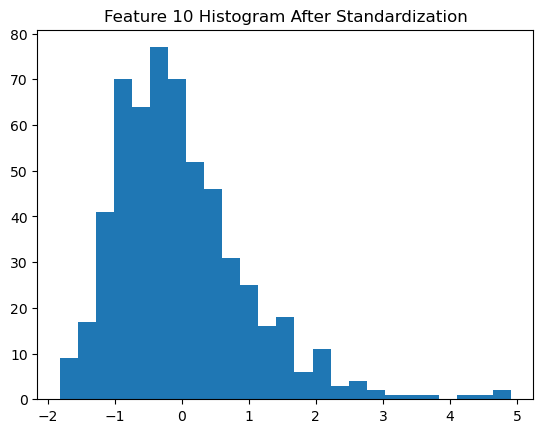

```python
from sklearn.preprocessing import StandardScaler
import matplotlib.pyplot as plt

df_before_std = df.copy()
print("Top 10 rows before standardization:")
print(df_before_std.head(10))

features = df.iloc[:, 2:]    # this excludes patient ID and label

scaler = StandardScaler()

features_scaled = scaler.fit_transform(features)

features_scaled_df = pd.DataFrame(features_scaled, columns=features.columns)

df.iloc[:, 2:] = features_scaled_df

print("Top 10 rows after standardization:")
print(df.head(10))

feature_10_data = df.iloc[:, 11]

plt.hist(feature_10_data, bins=25)
plt.title("Feature 10 Histogram After Standardization")
plt.show()
```

#### 6. What features have variance $< 0.1$? Remove any such features from the dataset.

```python
df_variance = features_scaled_df.var()

low_variance_features = list(df_variance[df_variance < 0.1].index)
print("Features with variance < 0.1:", low_variance_features)

df = df.drop(low_variance_features, axis = 1)

df.head()
```

```
Features with variance < 0.1: [16]
```

|  | 0 | 1 | 2 | 3 | 4 | 5 | 6 | 7 | 8 | 9 | ... | 22 | 23 | 24 | 25 | 26 | 27 | 28 | 29 | 30 | 31 |
| --- | --- | --- | --- | --- | --- | --- | --- | --- | --- | --- | --- | --- | --- | --- | --- | --- | --- | --- | --- | --- | --- |
| 0 | 842302 | M | 1.202173 | -2.254784 | 1.269934 | 0.984375 | 1.654470 | 3.283515 | -0.312539 | 2.532475 | ... | 1.992524 | -1.359293 | 2.462782 | 2.001237 | 1.307686 | 2.647038 | 2.109526 | 2.471938 | 2.792154 | 1.937015 |
| 1 | 842517 | M | 1.983101 | -0.363846 | 1.685955 | 1.908708 | -0.888374 | -0.487072 | 0.027222 | 0.548144 | ... | 1.908540 | -0.369203 | 1.654219 | 1.890489 | -0.375612 | -0.425209 | -0.146749 | 1.181350 | -0.248735 | 0.281190 |
| 2 | 84300903 | M | 1.716738 | 0.526609 | 1.566503 | 1.558884 | 0.989674 | 1.052926 | 1.515870 | 2.037231 | ... | 1.602754 | -0.023974 | 1.456779 | 1.456285 | 0.527407 | 1.100652 | 0.854974 | 2.107843 | 1.169032 | 0.201391 |
| 3 | 84348301 | M | -0.786469 | 0.303996 | -0.592687 | -0.764464 | 3.475104 | 3.402909 | 2.108634 | 1.451707 | ... | -0.262114 | 0.133984 | -0.223965 | -0.550021 | 3.394275 | 3.934303 | 1.989588 | -0.188884 | 6.138611 | 4.935010 |
| 4 | 84358402 | M | 1.898350 | -0.113085 | 1.776573 | 1.826229 | -0.041137 | 0.539340 | 1.523953 | 1.428493 | ... | 1.380951 | -1.466770 | 1.447377 | 1.220724 | 0.220556 | -0.307194 | 0.613179 | -0.188884 | -0.882870 | -0.397100 |

5 rows × 31 columns

#### 7. Which samples (as indicated by row number) are duplicate samples?

```python
duplicate_samples = df.duplicated()

if duplicate_samples.any():
    print(df_breast_cancer[duplicate_samples])
else:
    print("No duplicate samples found in the dataset.")
```

```
No duplicate samples found in the dataset.
```

#### 8. Use the standard deviation method to remove outliers. Apply the method to each feature individually and choose the data points which are an outlier in any of the features to remove. You can choose the lower and upper thresholds. Explain how you decided on the thresholds and what were the outlier samples removed from the dataset. (Don't forget the labels and patient IDs!)

```python
feature_columns = df.columns[2:]

outliers_index = pd.Series(False, index=df.index)

threshold = 3

for col in feature_columns:
    feature_data = df[col]
    data_mean, data_std = feature_data.mean(), feature_data.std()
    lower_bound = data_mean - threshold * data_std
    upper_bound = data_mean + threshold * data_std

    # for datasets that lie outside lower bound and upper bound
    is_outlier = (feature_data < lower_bound) | (feature_data > upper_bound)

    outliers_index = outliers_index | is_outlier

    print(f"Number of outliers in feature '{col}': {is_outlier.sum()}\n")

# to get indices of all samples
outlier_sample_indices = df.index[outliers_index].tolist()

print("Total number of outlier samples to remove:", len(outlier_sample_indices))
print("\nIndices of outlier samples:", outlier_sample_indices)

df = df.drop(index=outlier_sample_indices).reset_index(drop=True)

print("\nDataframe shape after removing outliers:", df.shape)
```

```
Number of outliers in feature '2': 7

Number of outliers in feature '3': 5

Number of outliers in feature '4': 7

Number of outliers in feature '5': 8

Number of outliers in feature '6': 6

Number of outliers in feature '7': 9

Number of outliers in feature '8': 12

Number of outliers in feature '9': 6

Number of outliers in feature '10': 5

Number of outliers in feature '11': 7

Number of outliers in feature '12': 9

Number of outliers in feature '13': 9

Number of outliers in feature '14': 12

Number of outliers in feature '15': 6

Number of outliers in feature '17': 12

Number of outliers in feature '18': 6

Number of outliers in feature '19': 7

Number of outliers in feature '20': 11

Number of outliers in feature '21': 10

Number of outliers in feature '22': 6

```

[output cut: 8 more lines]

```
Number of outliers in feature '27': 10

Number of outliers in feature '28': 7

Number of outliers in feature '29': 0

Number of outliers in feature '30': 10

Number of outliers in feature '31': 9

Total number of outlier samples to remove: 76

Indices of outlier samples: [0, 3, 9, 12, 14, 23, 25, 31, 35, 38, 42, 60, 68, 71, 72, 78, 82, 83, 105, 108, 112, 119, 122, 138, 146, 151, 152, 176, 180, 181, 190, 199, 202, 203, 212, 213, 214, 219, 232, 236, 239, 258, 259, 265, 272, 288, 290, 314, 318, 323, 339, 351, 352, 368, 370, 376, 379, 388, 38…

Dataframe shape after removing outliers: (493, 31)
```

**I set the threshold at 3, as used in statistical analyses which I think can identify values that are different from mean**

#### 9. Select a subset of the features using the ANOVA test. Plot a histogram of all the ANOVA scores and decide which features to keep. Print which features those are.

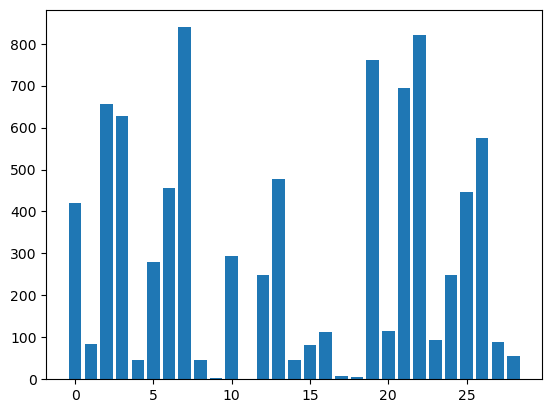

```
ANOVA F-scores for each feature:
2     421.016811
3      84.032565
4     655.167389
5     627.386608
6      46.635862
7     279.557327
8     455.563942
9     839.129194
10     47.142571
11      2.519804
12    293.997714
13      0.061070
14    248.738423
15    476.377806
```

[output cut: 16 more lines]

```python
from sklearn.feature_selection import SelectKBest, f_classif
from sklearn.preprocessing import LabelEncoder

X = df.iloc[:, 2:]
y = df.iloc[:, 1]

label_encoder = LabelEncoder()
y_encode = label_encoder.fit_transform(y)

fs = SelectKBest(score_func=f_classif, k='all')
fs.fit(X, y_encode)

scores = fs.scores_    # get the f-scores for each feature

plt.bar(range(len(scores)), scores)
plt.show()

feature_scores = pd.Series(scores, index=X.columns)
print("\nANOVA F-scores for each feature:")
print(feature_scores)

selected_features = feature_scores.index.tolist()    # selects all feature names

df = df.iloc[:, [0, 1] + [df.columns.get_loc(col) for col in selected_features]]
```

#### 10. After all the above, how many samples and features does the final dataset have?

```python
num_samples = df.shape[0]

num_features = df.shape[1] - 2

print(f"Final number of samples: {num_samples}")
print(f"Final number of features: {num_features}")
```

```
Final number of samples: 493
Final number of features: 29
```